# Jill’s ASSURE Analysis

## ASSURE Analysis Request

## ASSURE Analysis Specifications

| Study |
| --- |
| Multiple comparators and/or multiple outcomes. |

> Target: Cana Section 6.1

> Comparators: GLP1 Section 6.3

> Outcomes: sarcopenia Section 6.2

Study Period:  
All Time

Restrictions:  
Age - None

Analytic Methods:  
* Characterization  
* Propensity-matched comparative cohort on treatment  
* Self-controlled case series (SCCS)  
* Patient-level prediction

Databases:  
* 3 US Claims  
* 1 US EHR  
* Non-US Claims

# Characterization

## Cohort Incidence

- sarcopenia
- TAR: (start + 1) - (end + 0)

| database | personsAtRisk | personDays | personOutcomes | outcomes | incidenceProportionP100p | incidenceRateP100py |
| --- | --- | --- | --- | --- | --- | --- |
| IBM CCAE | 36500 | 9935691 | 0 | 0 | 0 | 0 |
| Healthverity CC | 189163 | 51143320 | 9 | 9 | 0.00475780147280387 | 0.00642752562798035 |
| OPTUM Extended DOD | 46603 | 11454671 | -5 | -5 | Any | Any |
| Optum EHR | 117355 | 19140138 | 5 | 5 | 0.00426057688210983 | 0.00954146725587871 |
| IBM MDCD | 15338 | 3670944 | -5 | -5 | Any | Any |
| IBM MDCR | 6161 | 1536690 | 0 | 0 | 0 | 0 |
| PharMetrics | 58894 | 16761396 | -5 | -5 | Any | Any |

## Cohort Demographics

- sarcopenia
- TAR: (NA + NA) - (NA + NA)

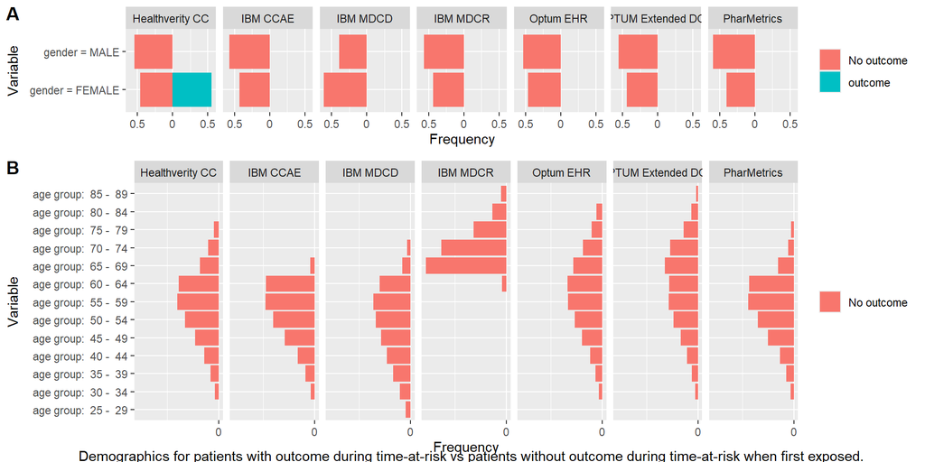

#### TAR: (cohort start + 1) - (cohort end + 0)

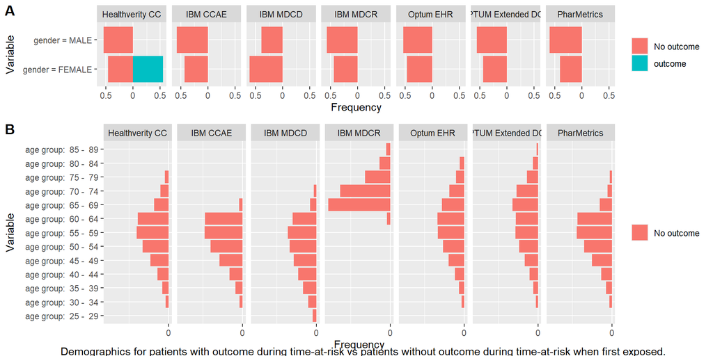

## Cohort Characterization

- sarcopenia
- TAR: (NA + NA) - (NA + NA)
- TAR: (cohort start + 1) - (cohort end + 0)

| database | covariateName | No Outcome | With Outcome | SMD |
| --- | --- | --- | --- | --- |
| IBM CCAE | condition_era group (ConditionGroupEraLongTerm) during day -365 through 0 days relative to index: Essential hypertension | 0.72897861 | 0 | 0 |
| IBM CCAE | condition_era group (ConditionGroupEraLongTerm) during day -365 through 0 days relative to index: Anxiety | 0.11305323 | 0 | 0 |
| IBM CCAE | condition_era group (ConditionGroupEraLongTerm) during day -365 through 0 days relative to index: Cerebral infarction | 0.01001149 | 0 | 0 |
| OPTUM Extended DOD | condition_era group (ConditionGroupEraLongTerm) during day -365 through 0 days relative to index: Essential hypertension | 0.80040314 | NA | 0 |
| OPTUM Extended DOD | condition_era group (ConditionGroupEraLongTerm) during day -365 through 0 days relative to index: Anxiety | 0.14021958 | NA | 0 |
| OPTUM Extended DOD | condition_era group (ConditionGroupEraLongTerm) during day -365 through 0 days relative to index: Cerebral infarction | 0.02333062 | 0 | 0 |
| Optum EHR | condition_era group (ConditionGroupEraLongTerm) during day -365 through 0 days relative to index: Essential hypertension | 0.65727724 | 1 | 0 |
| Optum EHR | condition_era group (ConditionGroupEraLongTerm) during day -365 through 0 days relative to index: Anxiety | 0.13197178 | NA | 0 |
| Optum EHR | condition_era group (ConditionGroupEraLongTerm) during day -365 through 0 days relative to index: Cerebral infarction | 0.01919636 | NA | 0 |
| IBM MDCD | condition_era group (ConditionGroupEraLongTerm) during day -365 through 0 days relative to index: Essential hypertension | 0.76582934 | NA | 0 |

[output cut: 11 more lines]

| database | covariateName | No Outcome | With Outcome | SMD |
| --- | --- | --- | --- | --- |
| IBM CCAE | condition_era group (ConditionGroupEraLongTerm) during day -365 through 0 days relative to index: Essential hypertension | 0.72897861 | 0 | 0 |
| IBM CCAE | condition_era group (ConditionGroupEraLongTerm) during day -365 through 0 days relative to index: Anxiety | 0.11305323 | 0 | 0 |
| IBM CCAE | condition_era group (ConditionGroupEraLongTerm) during day -365 through 0 days relative to index: Cerebral infarction | 0.01001149 | 0 | 0 |
| OPTUM Extended DOD | condition_era group (ConditionGroupEraLongTerm) during day -365 through 0 days relative to index: Essential hypertension | 0.80040314 | NA | 0 |
| OPTUM Extended DOD | condition_era group (ConditionGroupEraLongTerm) during day -365 through 0 days relative to index: Anxiety | 0.14021958 | NA | 0 |
| OPTUM Extended DOD | condition_era group (ConditionGroupEraLongTerm) during day -365 through 0 days relative to index: Cerebral infarction | 0.02333062 | 0 | 0 |
| Optum EHR | condition_era group (ConditionGroupEraLongTerm) during day -365 through 0 days relative to index: Essential hypertension | 0.65727724 | 1 | 0 |
| Optum EHR | condition_era group (ConditionGroupEraLongTerm) during day -365 through 0 days relative to index: Anxiety | 0.13197178 | NA | 0 |
| Optum EHR | condition_era group (ConditionGroupEraLongTerm) during day -365 through 0 days relative to index: Cerebral infarction | 0.01919636 | NA | 0 |
| IBM MDCD | condition_era group (ConditionGroupEraLongTerm) during day -365 through 0 days relative to index: Essential hypertension | 0.76582934 | NA | 0 |

[output cut: 11 more lines]

# Causal Inference

## Cohort Method

| Database | analysis | comparator | Overall Diagnostic |
| --- | --- | --- | --- |
| Healthverity CC | Cohort method, On treatment | GLP-1 receptor antagonists with prior t2d | Fail |
| IBM CCAE | Cohort method, On treatment | GLP-1 receptor antagonists with prior t2d | Fail |
| IBM MDCD | Cohort method, On treatment | GLP-1 receptor antagonists with prior t2d | Fail |
| IBM MDCR | Cohort method, On treatment | GLP-1 receptor antagonists with prior t2d | Fail |
| Optum EHR | Cohort method, On treatment | GLP-1 receptor antagonists with prior t2d | Pass |
| OPTUM Extended DOD | Cohort method, On treatment | GLP-1 receptor antagonists with prior t2d | Fail |
| PharMetrics | Cohort method, On treatment | GLP-1 receptor antagonists with prior t2d | Fail |

> Fail: Study failed ASSURE diagnostics

> Pass: Study passed without warnings

> Number: Passed wth Number of warnings

| database | comparator | description | calibratedRr | calibratedCi95Lb | calibratedCi95Ub | calibratedP | calibratedLogRr | calibratedSeLogRr |
| --- | --- | --- | --- | --- | --- | --- | --- | --- |
| Optum EHR | GLP-1 receptor antagonists with prior t2d | Cohort method, On treatment | 8.79443118891163 | 0.661255845469282 | 116.962323231502 | 0.0498275357287144 | 2.17411870172756 | 1.32029627991065 |

- Cohort method, On treatment

> Fail: Study failed ASSURE diagnostics

> Pass: Study passed without warnings

> Number: Passed wth Number of warnings

# Prediction

> AUROC: A measure of model discrimination. 1 is best. Probability a random person with the outcome has a higher risk than an random person without the outcome.

> e-stat: A measure of calibration. Smaller is better. How accurate the predicted risks are.

> brier: Overall error. Smaller is better.

# Conclusions

# Supplementary

# Cohorts

## Target Cana

> Full name: canagliflozin

**Cohort Definition**

### Cohort Definition

### Cohort Entry Events

People enter the cohort when observing any of the following:

1. drug exposures of ‘Assure Exposure - I - canagliflozin’.

### Cohort Exit

The cohort end date will be based on a continuous exposure to ‘Assure Exposure - I - canagliflozin’: allowing 30 days between exposures, adding 0 days after exposure ends, and using days supply and exposure end date for exposure duration.

### Cohort Eras

Remaining events will be combined into cohort eras if they are within 0 days of each other.

**Subset**

## Outcome sarcopenia

> Full name: sarcopenia 2016+

**Cohort Definition**

### Cohort Definition)

### Cohort Entry Events

People enter the cohort when observing any of the following:

1. condition occurrence of ‘sarcopenia, other specific muscle disorders’ for the first time in the person’s history, starting on or after January 1, 2016.
2. condition occurrence of any condition (including ‘sarcopenia, other specific muscle disorders’ source concepts) for the first time in the person’s history, starting on or after January 1, 2016; with at least 1 of the following criteria:
   1. having at least 1 condition occurrence of ‘[ase061] muscle weakness’, starting between 7 days before and 7 days after any condition start date; with at least 1 of the following criteria:
      1. having at least 1 condition occurrence of ‘[ase061] weight loss’, starting between 30 days before and 30 days after ‘[ase061] muscle weakness’ start date.
      2. having at least 1 observation of ‘[ase061] weight loss’, starting between 30 days before and 30 days after ‘[ase061] muscle weakness’ start date.
   2. having at least 1 condition occurrence of ‘[ase061] muscle atrophy’, starting between 30 days before and 30 days after any condition start date; with at least 1 of the following criteria:
      1. having at least 1 condition occurrence of ‘[ase061] weight loss’, starting between 30 days before and 30 days after ‘[ase061] muscle atrophy’ start date.
      2. having at least 1 observation of ‘[ase061] weight loss’, starting between 30 days before and 30 days after ‘[ase061] muscle atrophy’ start date.

Limit cohort entry events to the earliest event per person.

### Cohort Exit

The person exits the cohort at the end of continuous observation.

### Cohort Eras

Remaining events will be combined into cohort eras if they are within 0 days of each other.

## Comparator GLP1

> Full name: GLP-1 receptor antagonists

**Cohort Definition**

### Cohort Definition

### Cohort Entry Events

People enter the cohort when observing any of the following:

1. drug exposures of ‘[ASSURE] GLP-1 receptor antagonists’.

### Cohort Exit

The cohort end date will be based on a continuous exposure to ‘[ASSURE] GLP-1 receptor antagonists’: allowing 90 days between exposures, adding 0 days after exposure ends, and using days supply and exposure end date for exposure duration.

### Cohort Eras

Remaining events will be combined into cohort eras if they are within 0 days of each other.

**Cohort Definition**

### Subset (not used in SCCS)

prior t2d

# Protocol

[figure not shown]

ASSURE Standardized report